# Homework_3

Mari Sanders

2024-10-05

# Problem 1

```r
data("ny_noaa")

noaa_df <-
  ny_noaa %>%
  separate(date, into = c("year", "month", "day"), sep = "-") %>%

  mutate(tmax, tmax = as.integer(tmax) / 10) %>%
  mutate(tmin, tmin = as.integer(tmin)/ 10) %>%
  mutate(prcp, pcrp = as.integer(prcp)/ 10)

noaa_df %>%
  group_by(snow) %>%
  summarize(count = n())
```

```
## # A tibble: 282 × 2
##     snow   count
##    <int>   <int>
##  1   -13       1
##  2     0 2008508
##  3     3    8790
##  4     5    9748
##  5     8    9962
##  6    10    5106
##  7    13   23095
##  8    15    3672
##  9    18    3226
## 10    20    4797
## # ℹ 272 more rows
```

There is most commonly 0 mm of snow. This is because most days in NYC mostly doesn’t snow.

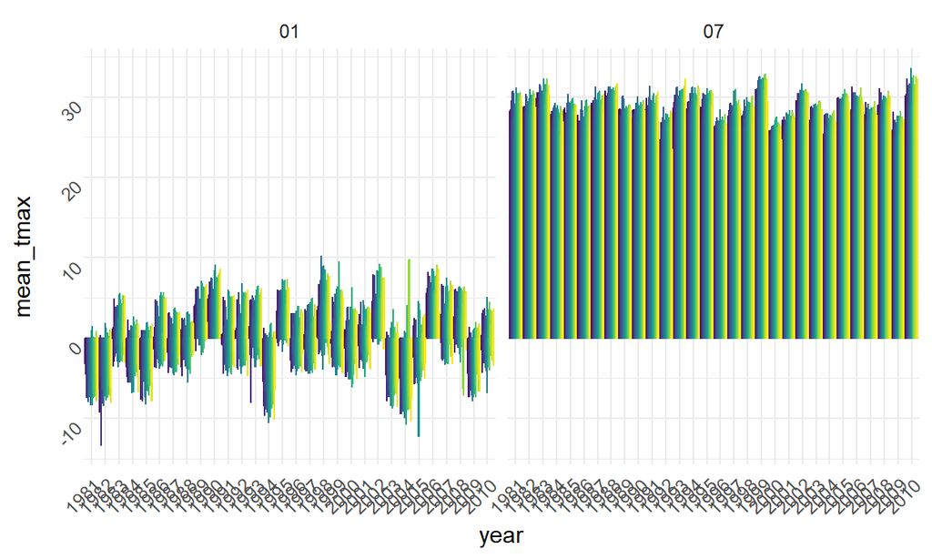

```r
noaa_df %>%
  filter(month == "01" | month == "07") %>%
  drop_na(tmax) %>%
  group_by(id, year, month) %>%
  summarize(mean_tmax = mean(tmax, na.rm = TRUE), .group = "none") %>%
   ggplot(aes(x = year, y = mean_tmax, color = id)) +
   geom_bar(stat = "identity", position = "dodge") +
  facet_grid(~month) + theme(legend.position = "none") + theme(axis.text = element_text(angle = 45, vjust = 1, hjust = 1))
```

The temperature in July seems to be much more predicable, with less range in the average maximum temperature. There seems to be a max temperature in 1982 that is extremely low compared to the other data. Additionally, in 2005, there was another average temperature in January that was a lot lower than the other data.

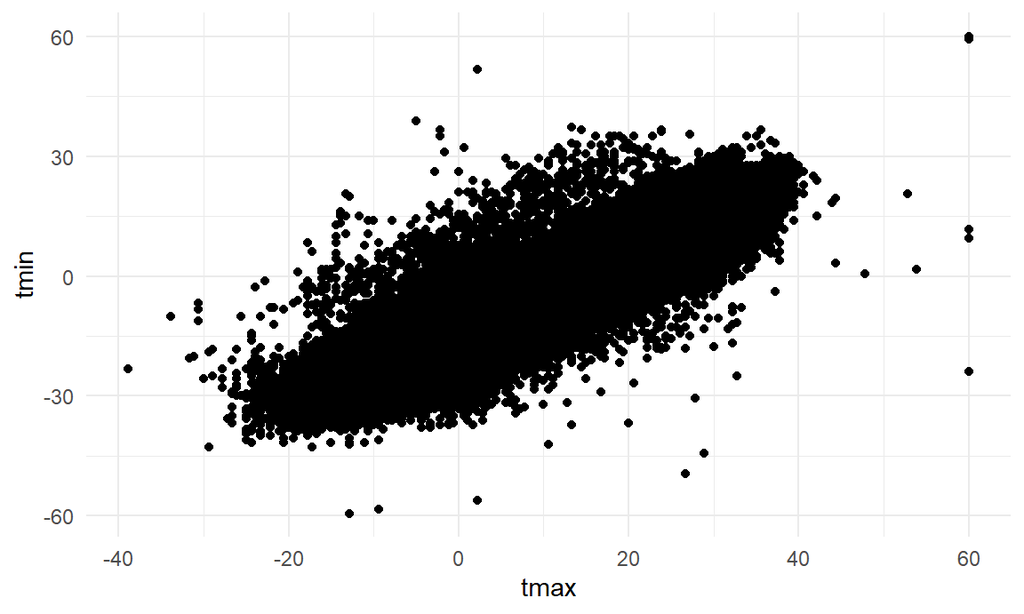

```r
noaa_df %>%
  ggplot(aes(x = tmax, y = tmin)) +
  geom_point()
```

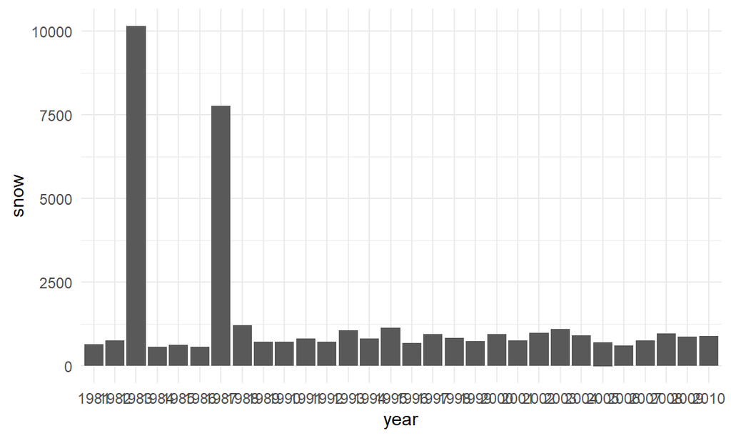

```r
noaa_df %>%
  group_by(year, snow) %>%
  filter(snow > 0 | snow < 100) %>%
  ggplot(aes(x = year, y = snow)) + geom_bar(stat = "identity", position = "dodge")
```

# Problem 2

```r
accel_df <-
  read_csv("data/nhanes_accel.csv") %>%
  janitor::clean_names()
```

```r
demographic_df <- read_csv("data/nhanes_covar.csv", skip = 4) %>%
  drop_na() %>%
  janitor::clean_names() %>%
  filter(age > 21) %>%
  mutate(sex, sex = as.factor(sex)) %>%
  mutate(education, education = as.factor(education))
demographic_accel_df <-
  left_join(demographic_df, accel_df, by = "seqn")
```

```r
demographic_accel_df %>%
  group_by(sex, education) %>%
  summarize(count = n()) %>%
  knitr::kable()
```

[output not shown]

| sex | education | count |
| --- | --- | --- |
| 1 | 1 | 27 |
| 1 | 2 | 34 |
| 1 | 3 | 54 |
| 2 | 1 | 28 |
| 2 | 2 | 23 |
| 2 | 3 | 59 |

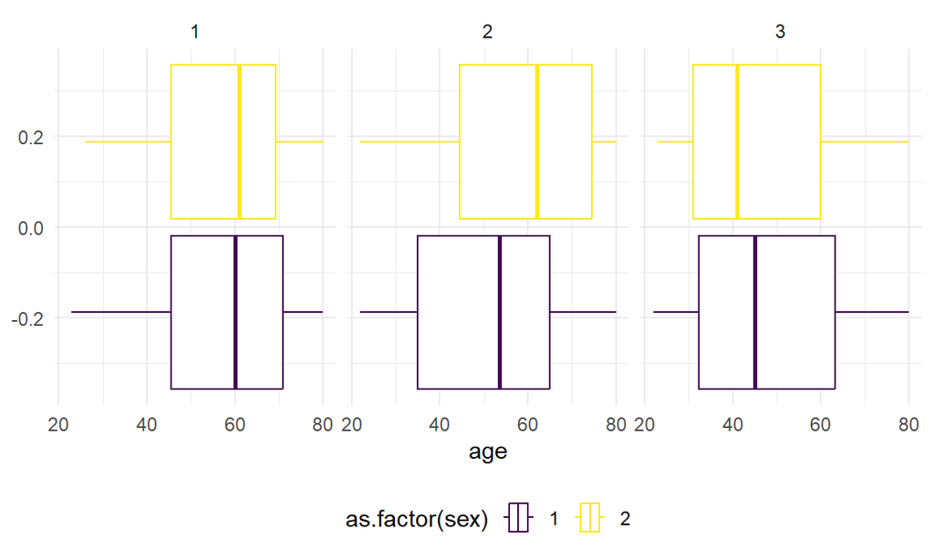

```r
demographic_accel_df %>%
  group_by(sex, age, education) %>%
  ggplot(aes(x = age, color = as.factor(sex))) +
  geom_boxplot() +
  facet_grid(~education)
```

The only age that is quite different is for education level 2. For females, the median age is a lot higher median age for males. Other than that, most of the ages are similar. All the distributions seem slightly skewed.

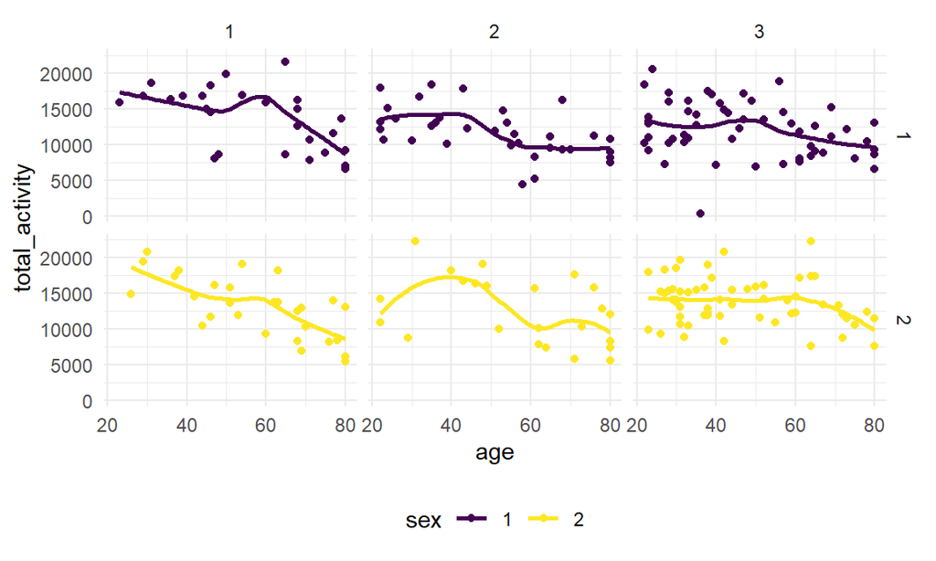

```r
demographic_accel_df %>%
  mutate(total_activity = rowSums(select(., starts_with("min")))) %>%
  ggplot(aes(x = age, y = total_activity, color = sex)) +
  geom_point() +
  facet_grid(sex~education) + geom_smooth(se = FALSE)
```

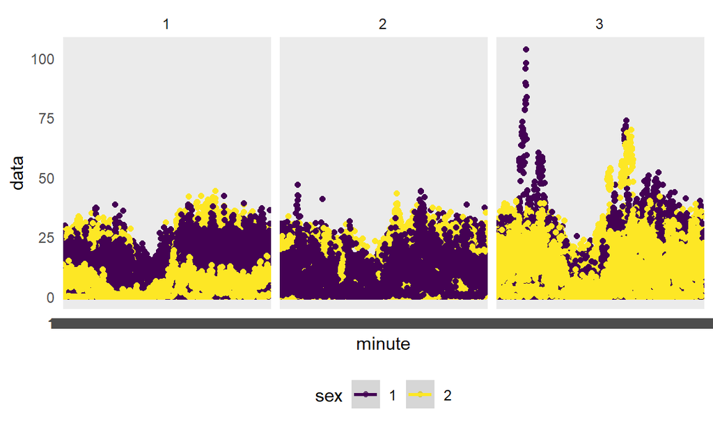

```r
demographic_accel_df %>%
  pivot_longer(
    cols = min1:min1440,
    values_to = "data",
    names_to = "minute",
    names_prefix = "min"
  ) %>% ggplot(aes(x = minute, y = data, color = sex)) + geom_point() + facet_grid(~education) + geom_smooth()
```

# Problem 3

```r
jan_2020 <- read_csv("data/Jan_2020_Citi.csv") %>%
  mutate(year = 2020) %>%
  mutate(month = "Jan") %>%
  relocate(year, month, .before = ride_id)
jan_2024 <- read_csv("data/Jan_2024_Citi.csv") %>%
  mutate(year = 2024) %>%
  mutate(month = "Jan") %>%
  relocate(year, month, .before = ride_id)
july_2020 <- read_csv("data/July_2020_Citi.csv") %>%
  mutate(year = 2020) %>%
  mutate(month = "July") %>%
  relocate(year, month, .before = ride_id)
july_2024 <- read_csv("data/July_2024_Citi.csv") %>%
  mutate(year = 2024) %>%
  mutate(month = "July") %>%
  relocate(year, month, .before = ride_id)
citi_bike_df <-
  bind_rows(jan_2020, july_2020, jan_2024, july_2024)
```

```r
citi_bike_df %>%
  group_by(year, month, member_casual) %>%
  summarize(count = n()) %>%
  knitr::kable()
```

| year | month | member_casual | count |
| --- | --- | --- | --- |
| 2020 | Jan | casual | 984 |
| 2020 | Jan | member | 11436 |
| 2020 | July | casual | 5637 |
| 2020 | July | member | 15411 |
| 2024 | Jan | casual | 2108 |
| 2024 | Jan | member | 16753 |
| 2024 | July | casual | 10894 |
| 2024 | July | member | 36262 |

OVerall, there were a lot more users in 2024 than in 2020. The highest amount of rides was in July 2024. THe lowest amount of rides was January of 2020.

```r
citi_bike_df %>%
  filter(month == "July" & year == "2024") %>%
  group_by(start_station_name) %>%
  summarize(count = n()) %>%  arrange(desc(count)) %>% head(5) %>% knitr::kable()
```

| start_station_name | count |
| --- | --- |
| Pier 61 at Chelsea Piers | 163 |
| University Pl & E 14 St | 155 |
| W 21 St & 6 Ave | 152 |
| West St & Chambers St | 150 |
| W 31 St & 7 Ave | 146 |

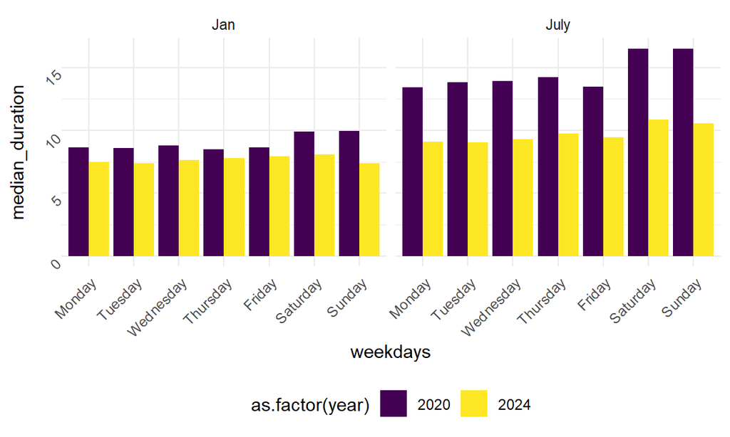

```r
citi_bike_df %>%
  mutate(weekdays = factor(weekdays,
                           levels = c("Monday", "Tuesday", "Wednesday", "Thursday", "Friday", "Saturday", "Sunday"),
                           ordered = TRUE)) %>%
  group_by(year, month, weekdays) %>%
  mutate(median_duration = median(duration)) %>% ggplot(aes(x = weekdays, y = median_duration, fill = as.factor(year))) + geom_bar(stat = "identity", position = "dodge") + facet_grid(~month) + theme(axis.text = element_text(angle = 45, vjust = 1, hjust = 1))
```

The median duration is higher in July 2020 than any other time in this graph. There seem to typically be longer duration rides on Saturday and Sunday than any other days of the week. The duration overall is less in 2024 than it was in 2020.

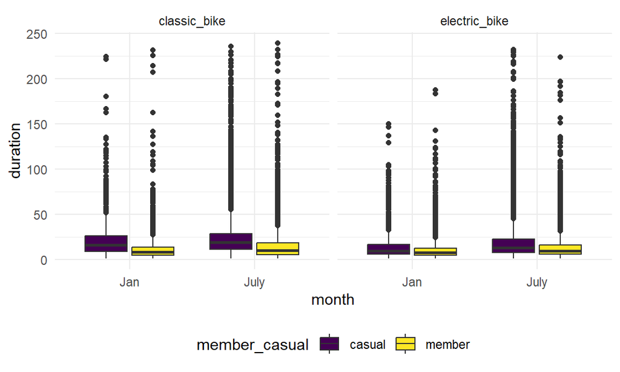

```r
citi_bike_df %>%
  group_by(month, member_casual, rideable_type, duration) %>%
  ggplot(aes(x = month, y = duration, fill = member_casual)) +
  geom_boxplot() +
  facet_grid(~rideable_type)
```